# Assignment 6: Using Sobol with an ODE

Katheryn Moya and Sarah Lam

2023-05-19

# Modeling Dynamic Forest Growth

Consider the following model of forest growth (where forest size in measured in units of carbon (C)):

dC/dt = r ∗ C for forests where C is below a threshold canopy closure dC/dt = g ∗ (1 − C/K) for forests where carbon is at or above the threshold canopy closure and K is a carrying capacity in units of carbon

The size of the forest (C), Canopy closure threshold and carrying capacity are all in units of carbon. Growth rates change from exponential (r) to linear (g) when it reaches the canopy closure threshold.

```r
# create and source forest growth model

source("/R/ESM232/esm232_a6/R/dforestgrowth.R") # on remote desktop

# source("~/Documents/MESM Year 2/ESM232/esm232_a6/R/dforestgrowth.R") # on my comp
```

# Run model for 300 years with no uncertainty

```r
# set initial forest size

Cinitial = 10

# come up with first set of parameters
r = 0.01
K = 250
closure = 50
g = 2

#convert to a dataframe
parms <- cbind.data.frame(r, K, closure, g)

# gets results for 300 years (evaluating every year)
years <-seq(from=1, to=300)

# run model for 300 years using ODE solver

results <- ode(y = Cinitial, times = years, func= dforestgrowth, parms = parms)
head(results)
```

```
##      time        1
## [1,]    1 10.00000
## [2,]    2 10.10050
## [3,]    3 10.20202
## [4,]    4 10.30455
## [5,]    5 10.40811
## [6,]    6 10.51271
```

```r
colnames(results)=c("year","C")

# save results as a dataframe for easier plotting
results <- as.data.frame(results)
```

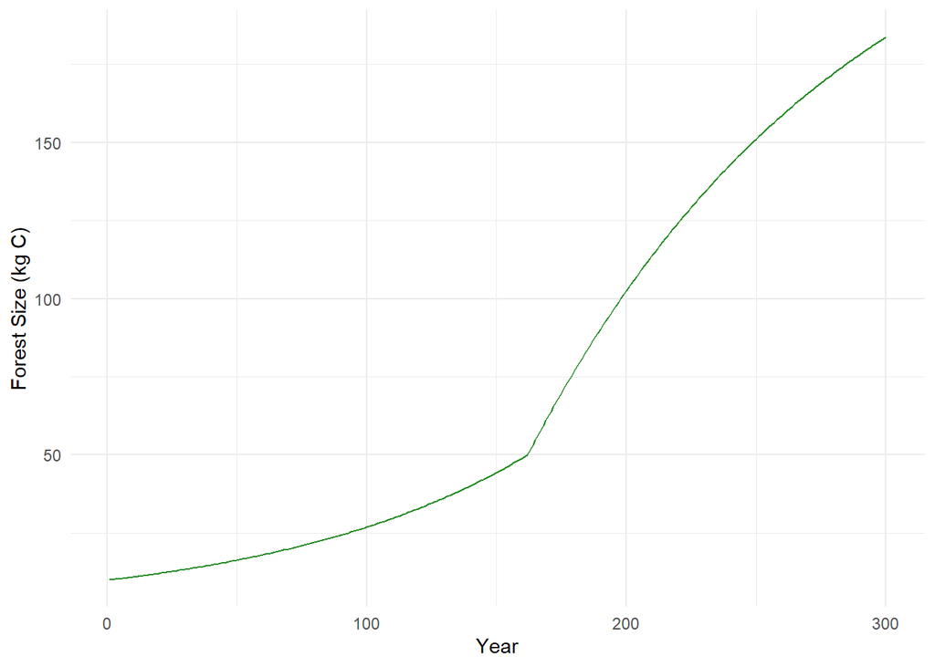

```r
# still have to make pretty

ggplot(results, aes(year, C)) +
  geom_line(color = "forestgreen") +
  labs(x = "Year",
       y = "Forest Size (kg C)") +
  theme_minimal()
```